# I piloti di ‘Formula Uno’ nel tempo e nello spazio

02/02/2022

## Analisi Formula 1

La ‘Formula 1’ è la massima categoria di vetture monoposto a ruote scoperte da corsa su circuito. Viene creata nel 1948 e il primo campionato mondiale avviene nel 1950, con avvincenti gare sparse per tutto il mondo e vantando i migliori di piloti in circolazione, considerata ormai la massima espressione delle corse automobilistiche. Da allora ogni anno è stato organizzato un campionato, con cambi di regole, diversi circuiti e nuovi piloti.

- Come la ‘Formula 1’ ha vissuto nello spazio tenedo conto delle nazioni
- Come il sistema di punteggio della ‘Formula 1’ è cambiato nel tempo e come ha influenzato i record storici, in particolare in relazione ai piloti ‘Hamilton’ e ‘Schumacher’

## Le nazioni per numero di gare ospitate

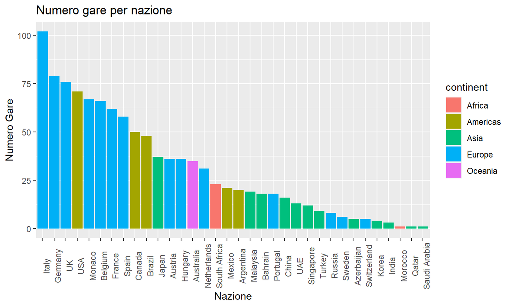

## Top 30 città per numero gare ospitate

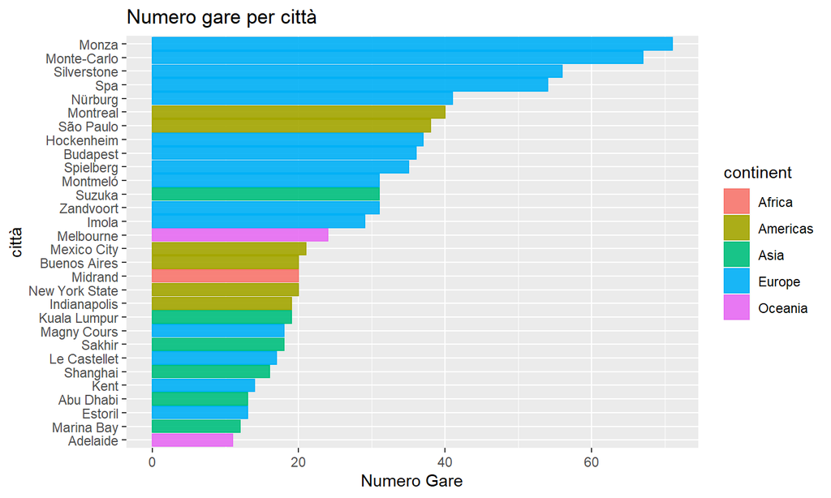

## Di quale nazionalità sono i piloti

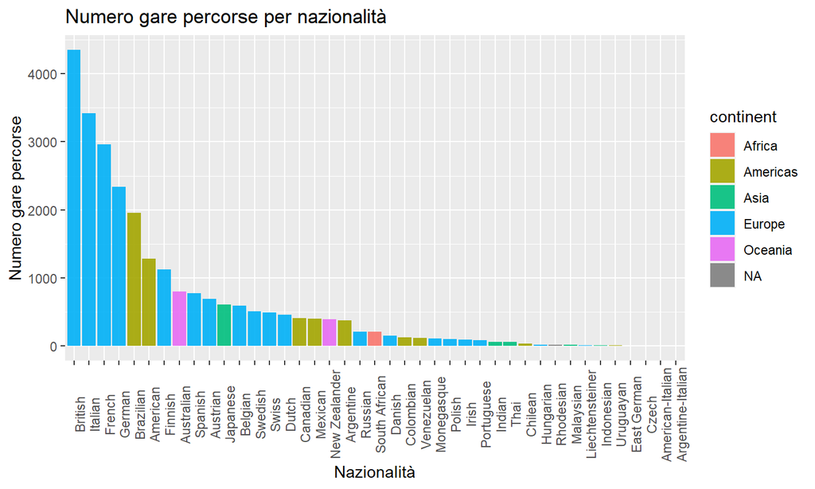

## Di quale nazionalità sono i piloti

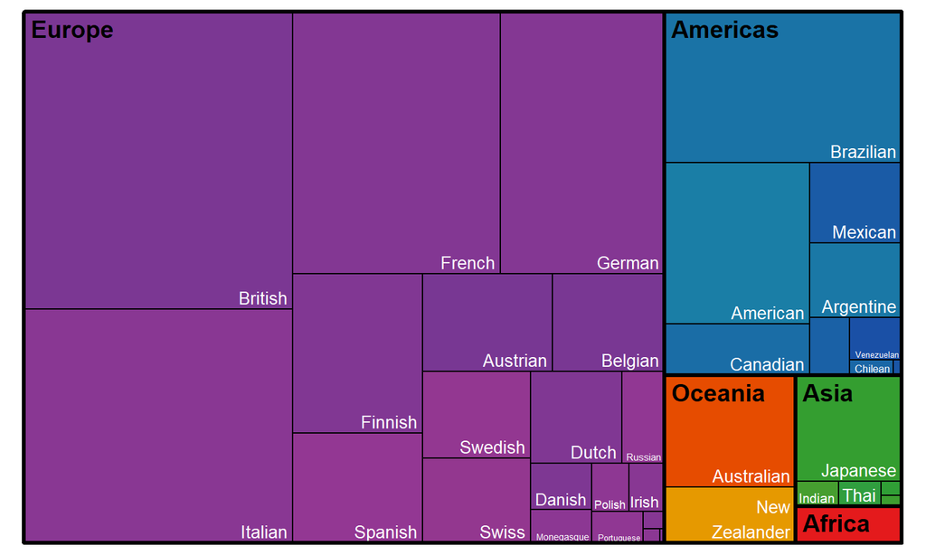

## Stagioni corse per nazionalità del costruttore

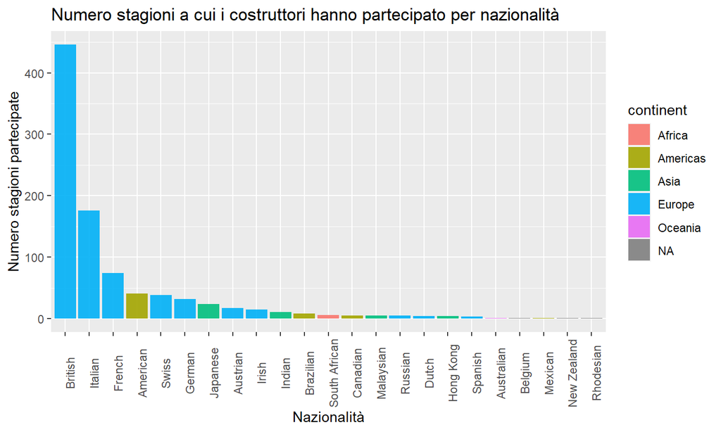

## Come si correlano questi dati

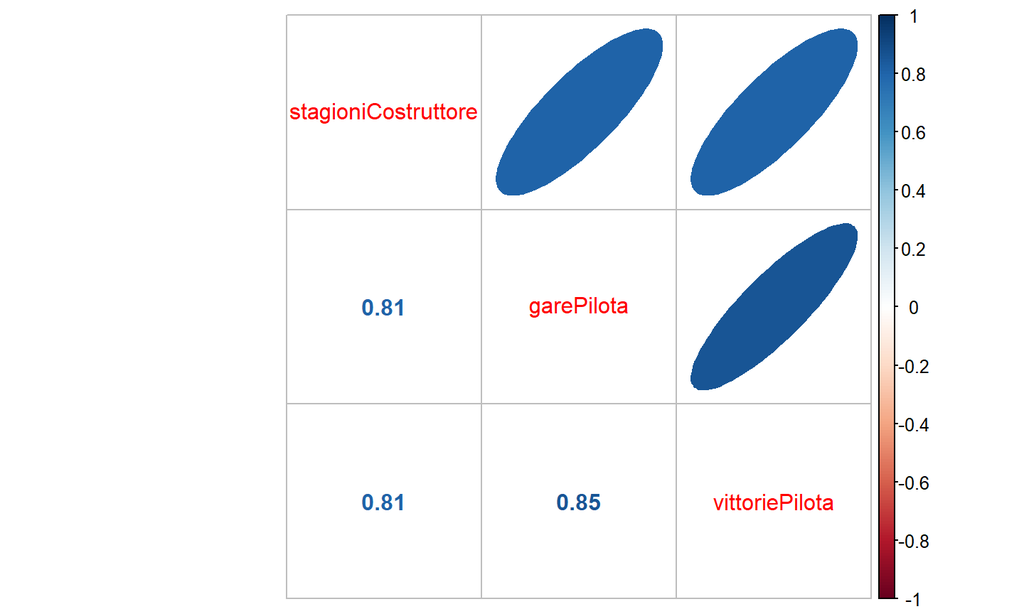

## Sistema di punteggio nella storia

Negli anni il sistema di assegnazioni dei punti è mutato diverse volte. I punti assegnati sono determinati dalla posizione di arrivo a fine gara. L’ammontare di punti è variato molto con il trascorrere del tempo, nel primo campionato ufficiale del 1950 venivano assegnati 8 punti per una vittoria a scalare fino a 2 punti alla quinta posizione, intorno agli anni 90 il vincitore guadagnava 10 punti in classifica e anche il sesto a concludere la gara prendeva un punto, fino ad oggi che il vincitore prendere 25 punti e vengono premiati primi 10. Negli anni, inoltre, sono stati testati diversi ‘punti bonus’ che vengono assegnati secondo regole aggiuntive.

## Chi ha segnato più punti con il sistema di punti nella storia

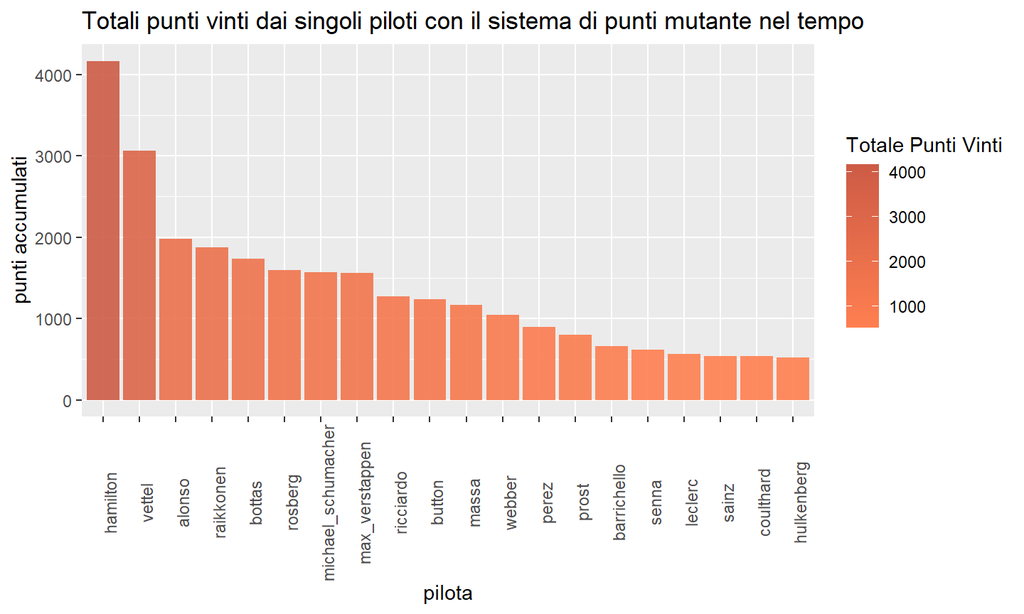

## Modernizzazione dei punteggi storici

Cosa succede se oggi ricalcoliamo i punteggi di tutta la storia della ‘Formula UNO’ adattando il formato a quello moderno, senza però tenere conto delle regole per cui i piloti una volta non competevano.

## Chi ha segnato più punti con il sistema di punti corrente

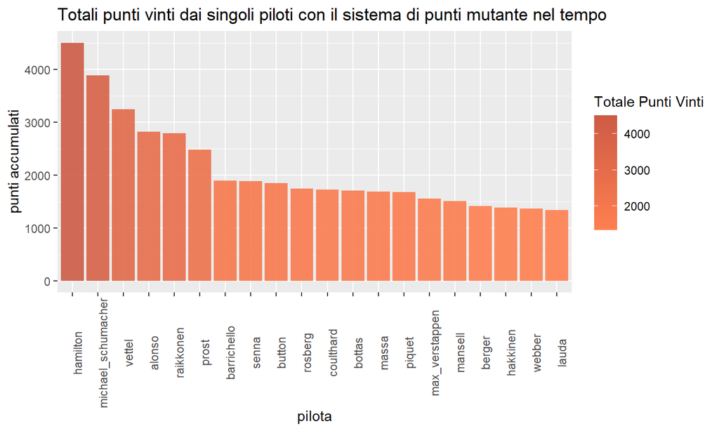

## Differenze tra vecchio punteggio e nuovo

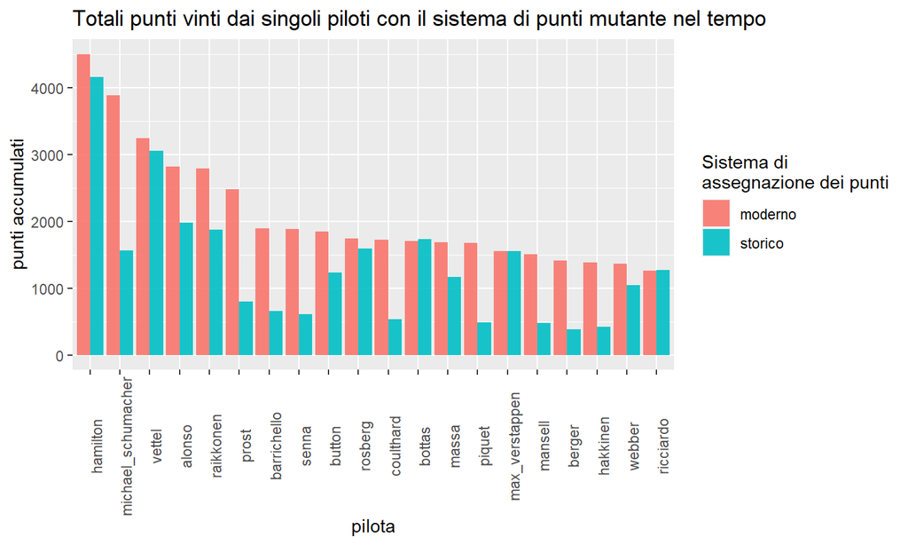

## Quanto vale un punto moderno rispetto ad un punto storico

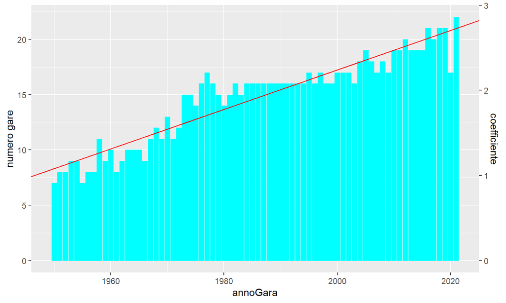

## Quanto vale un punto moderno rispetto ad un punto storico

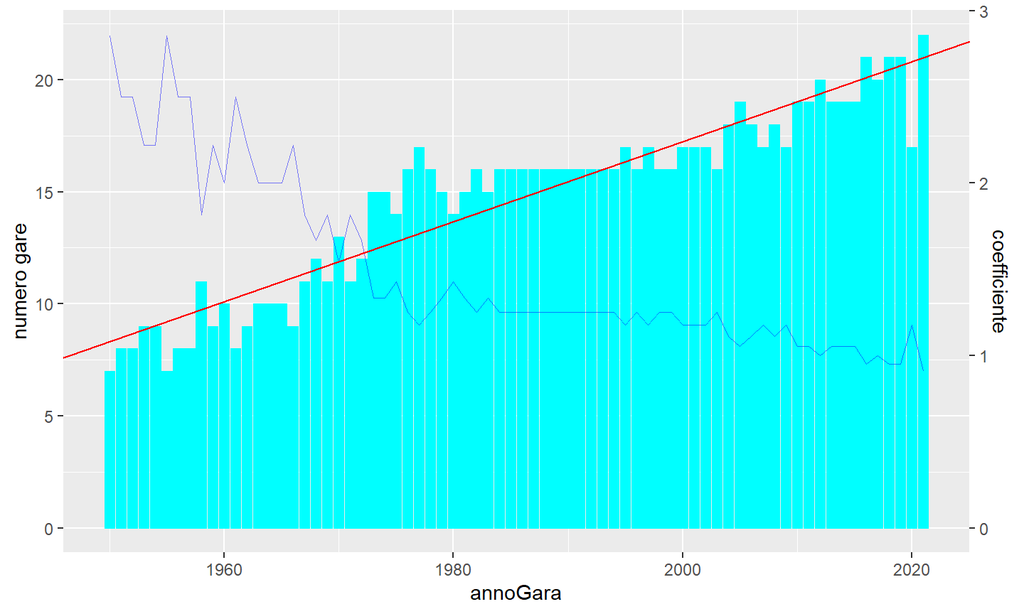

## Normalizzare lo storico dei punti rispetto al numero di gare

Grazie a questo coefficiente posso evalutare sullo stesso piano di merito un campionato con un numero diverso di gare rispetto ad un altro.

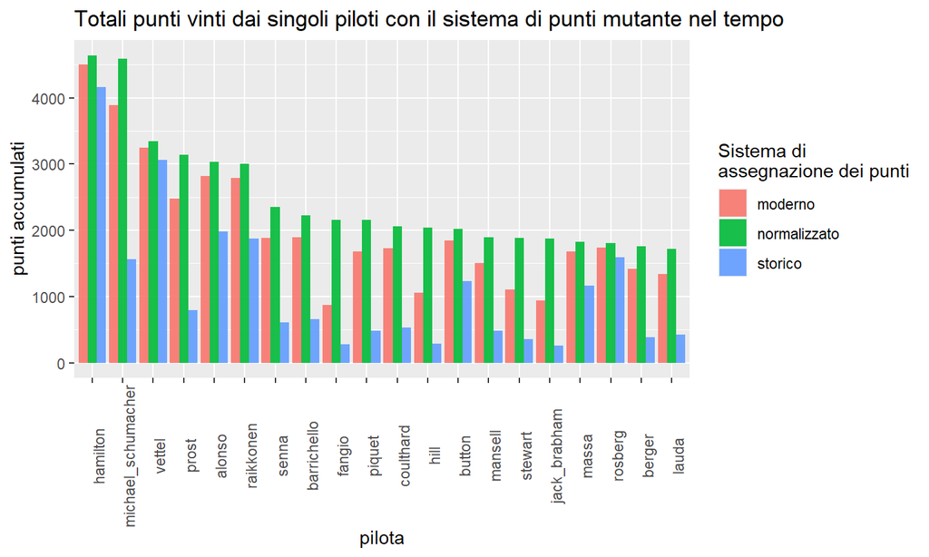

## Come sono distribuite le vittorie del campionato piloti tra i costruttori

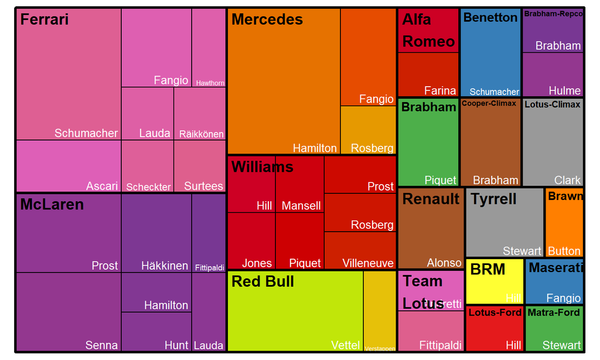

## FINE

Grazie per l’attenzione